# Risk Factor Analysis

## Outcome Variable

**Outcome Variable:** ever_wasted

## Predictor Variables

**Intervention Variable:** mage

**Adjustment Set:**

- arm
- meducyrs
- feducyrs
- hhwealth_quart
- W_mhtcm
- W_nrooms
- W_nchldlt5
- impfloor
- impsan
- safeh20
- delta_meducyrs
- delta_feducyrs
- delta_hhwealth_quart
- delta_W_mhtcm
- delta_W_nrooms
- delta_W_nchldlt5
- delta_impfloor
- delta_impsan
- delta_safeh20

## Stratifying Variables

The analysis was stratified on these variable(s):

- agecat
- studyid
- country

## Data Summary

| agecat | studyid | country | mage | ever_wasted | n_cell | n |
| --- | --- | --- | --- | --- | --- | --- |
| 0-24 months | ki0047075b-MAL-ED | BANGLADESH | <25 | 0 | 85 | 263 |
| 0-24 months | ki0047075b-MAL-ED | BANGLADESH | <25 | 1 | 39 | 263 |
| 0-24 months | ki0047075b-MAL-ED | BANGLADESH | [25-30) | 0 | 63 | 263 |
| 0-24 months | ki0047075b-MAL-ED | BANGLADESH | [25-30) | 1 | 30 | 263 |
| 0-24 months | ki0047075b-MAL-ED | BANGLADESH | >=30 | 0 | 28 | 263 |
| 0-24 months | ki0047075b-MAL-ED | BANGLADESH | >=30 | 1 | 18 | 263 |
| 0-24 months | ki0047075b-MAL-ED | BRAZIL | <25 | 0 | 110 | 233 |
| 0-24 months | ki0047075b-MAL-ED | BRAZIL | <25 | 1 | 7 | 233 |
| 0-24 months | ki0047075b-MAL-ED | BRAZIL | [25-30) | 0 | 57 | 233 |
| 0-24 months | ki0047075b-MAL-ED | BRAZIL | [25-30) | 1 | 8 | 233 |
| 0-24 months | ki0047075b-MAL-ED | BRAZIL | >=30 | 0 | 47 | 233 |
| 0-24 months | ki0047075b-MAL-ED | BRAZIL | >=30 | 1 | 4 | 233 |
| 0-24 months | ki0047075b-MAL-ED | INDIA | <25 | 0 | 76 | 249 |
| 0-24 months | ki0047075b-MAL-ED | INDIA | <25 | 1 | 69 | 249 |
| 0-24 months | ki0047075b-MAL-ED | INDIA | [25-30) | 0 | 41 | 249 |
| 0-24 months | ki0047075b-MAL-ED | INDIA | [25-30) | 1 | 42 | 249 |
| 0-24 months | ki0047075b-MAL-ED | INDIA | >=30 | 0 | 15 | 249 |
| 0-24 months | ki0047075b-MAL-ED | INDIA | >=30 | 1 | 6 | 249 |
| 0-24 months | ki0047075b-MAL-ED | NEPAL | <25 | 0 | 38 | 240 |
| 0-24 months | ki0047075b-MAL-ED | NEPAL | <25 | 1 | 28 | 240 |
| 0-24 months | ki0047075b-MAL-ED | NEPAL | [25-30) | 0 | 98 | 240 |
| 0-24 months | ki0047075b-MAL-ED | NEPAL | [25-30) | 1 | 30 | 240 |
| 0-24 months | ki0047075b-MAL-ED | NEPAL | >=30 | 0 | 35 | 240 |
| 0-24 months | ki0047075b-MAL-ED | NEPAL | >=30 | 1 | 11 | 240 |
| 0-24 months | ki0047075b-MAL-ED | PERU | <25 | 0 | 156 | 302 |
| 0-24 months | ki0047075b-MAL-ED | PERU | <25 | 1 | 15 | 302 |
| 0-24 months | ki0047075b-MAL-ED | PERU | [25-30) | 0 | 58 | 302 |
| 0-24 months | ki0047075b-MAL-ED | PERU | [25-30) | 1 | 6 | 302 |
| 0-24 months | ki0047075b-MAL-ED | PERU | >=30 | 0 | 62 | 302 |
| 0-24 months | ki0047075b-MAL-ED | PERU | >=30 | 1 | 5 | 302 |

[output cut: 450 more lines]

The following strata were considered:

- agecat: 0-24 months, studyid: ki0047075b-MAL-ED, country: BANGLADESH
- agecat: 0-24 months, studyid: ki0047075b-MAL-ED, country: BRAZIL
- agecat: 0-24 months, studyid: ki0047075b-MAL-ED, country: INDIA
- agecat: 0-24 months, studyid: ki0047075b-MAL-ED, country: NEPAL
- agecat: 0-24 months, studyid: ki0047075b-MAL-ED, country: PERU
- agecat: 0-24 months, studyid: ki0047075b-MAL-ED, country: SOUTH AFRICA
- agecat: 0-24 months, studyid: ki0047075b-MAL-ED, country: TANZANIA, UNITED REPUBLIC OF
- agecat: 0-24 months, studyid: ki1000108-CMC-V-BCS-2002, country: INDIA
- agecat: 0-24 months, studyid: ki1000108-IRC, country: INDIA
- agecat: 0-24 months, studyid: ki1000109-EE, country: PAKISTAN
- agecat: 0-24 months, studyid: ki1000304b-SAS-CompFeed, country: INDIA
- agecat: 0-24 months, studyid: ki1000304b-SAS-FoodSuppl, country: INDIA
- agecat: 0-24 months, studyid: ki1017093-NIH-Birth, country: BANGLADESH
- agecat: 0-24 months, studyid: ki1017093b-PROVIDE, country: BANGLADESH
- agecat: 0-24 months, studyid: ki1017093c-NIH-Crypto, country: BANGLADESH
- agecat: 0-24 months, studyid: ki1066203-TanzaniaChild2, country: TANZANIA, UNITED REPUBLIC OF
- agecat: 0-24 months, studyid: ki1101329-Keneba, country: GAMBIA
- agecat: 0-24 months, studyid: ki1112895-Guatemala BSC, country: GUATEMALA
- agecat: 0-24 months, studyid: ki1112895-iLiNS-Zinc, country: BURKINA FASO
- agecat: 0-24 months, studyid: ki1113344-GMS-Nepal, country: NEPAL
- agecat: 0-24 months, studyid: ki1119695-PROBIT, country: BELARUS
- agecat: 0-24 months, studyid: ki1126311-ZVITAMBO, country: ZIMBABWE
- agecat: 0-24 months, studyid: ki1135781-COHORTS, country: GUATEMALA
- agecat: 0-24 months, studyid: ki1135781-COHORTS, country: INDIA
- agecat: 0-24 months, studyid: ki1135781-COHORTS, country: PHILIPPINES
- agecat: 0-24 months, studyid: ki1148112-LCNI-5, country: MALAWI
- agecat: 0-24 months, studyid: kiGH5241-JiVitA-3, country: BANGLADESH
- agecat: 0-6 months, studyid: ki0047075b-MAL-ED, country: BANGLADESH
- agecat: 0-6 months, studyid: ki0047075b-MAL-ED, country: BRAZIL
- agecat: 0-6 months, studyid: ki0047075b-MAL-ED, country: INDIA
- agecat: 0-6 months, studyid: ki0047075b-MAL-ED, country: NEPAL
- agecat: 0-6 months, studyid: ki0047075b-MAL-ED, country: PERU
- agecat: 0-6 months, studyid: ki0047075b-MAL-ED, country: SOUTH AFRICA
- agecat: 0-6 months, studyid: ki0047075b-MAL-ED, country: TANZANIA, UNITED REPUBLIC OF
- agecat: 0-6 months, studyid: ki1000108-CMC-V-BCS-2002, country: INDIA
- agecat: 0-6 months, studyid: ki1000108-IRC, country: INDIA
- agecat: 0-6 months, studyid: ki1000109-EE, country: PAKISTAN
- agecat: 0-6 months, studyid: ki1000304b-SAS-CompFeed, country: INDIA
- agecat: 0-6 months, studyid: ki1000304b-SAS-FoodSuppl, country: INDIA
- agecat: 0-6 months, studyid: ki1017093-NIH-Birth, country: BANGLADESH
- agecat: 0-6 months, studyid: ki1017093b-PROVIDE, country: BANGLADESH
- agecat: 0-6 months, studyid: ki1017093c-NIH-Crypto, country: BANGLADESH
- agecat: 0-6 months, studyid: ki1066203-TanzaniaChild2, country: TANZANIA, UNITED REPUBLIC OF
- agecat: 0-6 months, studyid: ki1101329-Keneba, country: GAMBIA
- agecat: 0-6 months, studyid: ki1112895-Guatemala BSC, country: GUATEMALA
- agecat: 0-6 months, studyid: ki1113344-GMS-Nepal, country: NEPAL
- agecat: 0-6 months, studyid: ki1119695-PROBIT, country: BELARUS
- agecat: 0-6 months, studyid: ki1126311-ZVITAMBO, country: ZIMBABWE
- agecat: 0-6 months, studyid: ki1135781-COHORTS, country: GUATEMALA
- agecat: 0-6 months, studyid: ki1135781-COHORTS, country: INDIA
- agecat: 0-6 months, studyid: ki1135781-COHORTS, country: PHILIPPINES
- agecat: 0-6 months, studyid: ki1148112-LCNI-5, country: MALAWI
- agecat: 0-6 months, studyid: kiGH5241-JiVitA-3, country: BANGLADESH
- agecat: 6-24 months, studyid: ki0047075b-MAL-ED, country: BANGLADESH
- agecat: 6-24 months, studyid: ki0047075b-MAL-ED, country: BRAZIL
- agecat: 6-24 months, studyid: ki0047075b-MAL-ED, country: INDIA
- agecat: 6-24 months, studyid: ki0047075b-MAL-ED, country: NEPAL
- agecat: 6-24 months, studyid: ki0047075b-MAL-ED, country: PERU
- agecat: 6-24 months, studyid: ki0047075b-MAL-ED, country: SOUTH AFRICA
- agecat: 6-24 months, studyid: ki0047075b-MAL-ED, country: TANZANIA, UNITED REPUBLIC OF
- agecat: 6-24 months, studyid: ki1000108-CMC-V-BCS-2002, country: INDIA
- agecat: 6-24 months, studyid: ki1000108-IRC, country: INDIA
- agecat: 6-24 months, studyid: ki1000109-EE, country: PAKISTAN
- agecat: 6-24 months, studyid: ki1000304b-SAS-CompFeed, country: INDIA
- agecat: 6-24 months, studyid: ki1000304b-SAS-FoodSuppl, country: INDIA
- agecat: 6-24 months, studyid: ki1017093-NIH-Birth, country: BANGLADESH
- agecat: 6-24 months, studyid: ki1017093b-PROVIDE, country: BANGLADESH
- agecat: 6-24 months, studyid: ki1017093c-NIH-Crypto, country: BANGLADESH
- agecat: 6-24 months, studyid: ki1066203-TanzaniaChild2, country: TANZANIA, UNITED REPUBLIC OF
- agecat: 6-24 months, studyid: ki1101329-Keneba, country: GAMBIA
- agecat: 6-24 months, studyid: ki1112895-Guatemala BSC, country: GUATEMALA
- agecat: 6-24 months, studyid: ki1112895-iLiNS-Zinc, country: BURKINA FASO
- agecat: 6-24 months, studyid: ki1113344-GMS-Nepal, country: NEPAL
- agecat: 6-24 months, studyid: ki1119695-PROBIT, country: BELARUS
- agecat: 6-24 months, studyid: ki1126311-ZVITAMBO, country: ZIMBABWE
- agecat: 6-24 months, studyid: ki1135781-COHORTS, country: GUATEMALA
- agecat: 6-24 months, studyid: ki1135781-COHORTS, country: INDIA
- agecat: 6-24 months, studyid: ki1135781-COHORTS, country: PHILIPPINES
- agecat: 6-24 months, studyid: ki1148112-LCNI-5, country: MALAWI
- agecat: 6-24 months, studyid: kiGH5241-JiVitA-3, country: BANGLADESH

### Dropped Strata

Some strata were dropped due to rare outcomes:

- agecat: 0-24 months, studyid: ki0047075b-MAL-ED, country: BRAZIL
- agecat: 0-6 months, studyid: ki0047075b-MAL-ED, country: BRAZIL
- agecat: 0-6 months, studyid: ki0047075b-MAL-ED, country: PERU
- agecat: 0-6 months, studyid: ki0047075b-MAL-ED, country: TANZANIA, UNITED REPUBLIC OF
- agecat: 0-6 months, studyid: ki1112895-Guatemala BSC, country: GUATEMALA
- agecat: 0-6 months, studyid: ki1148112-LCNI-5, country: MALAWI
- agecat: 6-24 months, studyid: ki0047075b-MAL-ED, country: BRAZIL
- agecat: 6-24 months, studyid: ki0047075b-MAL-ED, country: INDIA
- agecat: 6-24 months, studyid: ki0047075b-MAL-ED, country: NEPAL
- agecat: 6-24 months, studyid: ki0047075b-MAL-ED, country: PERU
- agecat: 6-24 months, studyid: ki1112895-Guatemala BSC, country: GUATEMALA

## Methods Detail

We’re interested in the causal parameters $E[Y_a]$ for all values of $a \in \mathcal{A}$. These parameters represent the mean outcome if, possibly contrary to fact, we intervened to set all units to have $A=a$. Under the randomization and positivity assumptions, these are identified by the statistical parameters $\psi_a=E_W[E_{Y|A,W}(Y|A=a,W)]$. In addition, we’re interested in the mean of $Y$, $E[Y]$ under no intervention (the observed mean). We will estimate these parameters by using SuperLearner to fit the relevant likelihood factors – $E_{Y|A,W}(Y|A=a,W)$ and $p(A=a|W)$, and then updating our likelihood fit using a joint TMLE.

For unadjusted analyses ($W=\{\}$), initial likelihoods were estimated using Lrnr_glm to estimate the simple $E(Y|A)$ and Lrnr_mean to estimate $p(A)$. For adjusted analyses, a small library containing Lrnr_glmnet, Lrnr_xgboost, and Lrnr_mean was used.

Having estimated these parameters, we will then use the delta method to estimate relative risks and attributable risks relative to a prespecified baseline level of $A$.

# Results Detail

## Results Plots

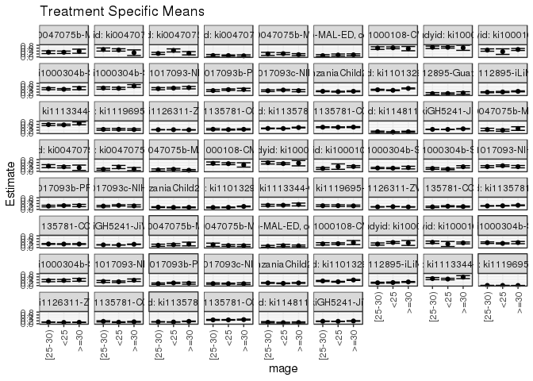

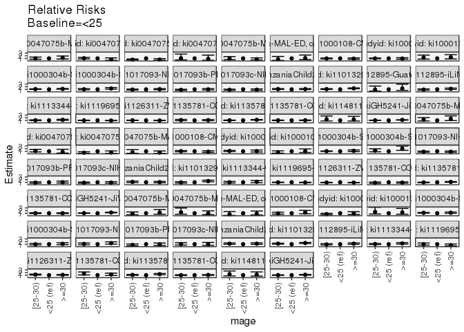

[figure not shown]

[figure not shown]

## Results Table

### Parameter: TSM

| agecat | studyid | country | intervention_level | baseline_level | estimate | ci_lower | ci_upper |
| --- | --- | --- | --- | --- | --- | --- | --- |
| 0-24 months | ki0047075b-MAL-ED | BANGLADESH | <25 | NA | 0.3159020 | 0.2341526 | 0.3976514 |
| 0-24 months | ki0047075b-MAL-ED | BANGLADESH | [25-30) | NA | 0.3215371 | 0.2267325 | 0.4163418 |
| 0-24 months | ki0047075b-MAL-ED | BANGLADESH | >=30 | NA | 0.3894919 | 0.2497687 | 0.5292152 |
| 0-24 months | ki0047075b-MAL-ED | INDIA | <25 | NA | 0.4758621 | 0.3944102 | 0.5573140 |
| 0-24 months | ki0047075b-MAL-ED | INDIA | [25-30) | NA | 0.5060241 | 0.3982483 | 0.6137999 |
| 0-24 months | ki0047075b-MAL-ED | INDIA | >=30 | NA | 0.2857143 | 0.0921103 | 0.4793182 |
| 0-24 months | ki0047075b-MAL-ED | NEPAL | <25 | NA | 0.4434284 | 0.3374704 | 0.5493863 |
| 0-24 months | ki0047075b-MAL-ED | NEPAL | [25-30) | NA | 0.2364142 | 0.1655996 | 0.3072287 |
| 0-24 months | ki0047075b-MAL-ED | NEPAL | >=30 | NA | 0.2467620 | 0.1333419 | 0.3601820 |
| 0-24 months | ki0047075b-MAL-ED | PERU | <25 | NA | 0.0877193 | 0.0452493 | 0.1301893 |
| 0-24 months | ki0047075b-MAL-ED | PERU | [25-30) | NA | 0.0937500 | 0.0222200 | 0.1652800 |
| 0-24 months | ki0047075b-MAL-ED | PERU | >=30 | NA | 0.0746269 | 0.0115984 | 0.1376554 |
| 0-24 months | ki0047075b-MAL-ED | SOUTH AFRICA | <25 | NA | 0.2214765 | 0.1546957 | 0.2882573 |
| 0-24 months | ki0047075b-MAL-ED | SOUTH AFRICA | [25-30) | NA | 0.2068966 | 0.1024792 | 0.3113139 |
| 0-24 months | ki0047075b-MAL-ED | SOUTH AFRICA | >=30 | NA | 0.1523810 | 0.0835290 | 0.2212329 |
| 0-24 months | ki0047075b-MAL-ED | TANZANIA, UNITED REPUBLIC OF | <25 | NA | 0.1279070 | 0.0571839 | 0.1986300 |
| 0-24 months | ki0047075b-MAL-ED | TANZANIA, UNITED REPUBLIC OF | [25-30) | NA | 0.0869565 | 0.0203443 | 0.1535687 |
| 0-24 months | ki0047075b-MAL-ED | TANZANIA, UNITED REPUBLIC OF | >=30 | NA | 0.1415094 | 0.0750297 | 0.2079892 |
| 0-24 months | ki1000108-CMC-V-BCS-2002 | INDIA | <25 | NA | 0.6254863 | 0.5618299 | 0.6891426 |
| 0-24 months | ki1000108-CMC-V-BCS-2002 | INDIA | [25-30) | NA | 0.6065265 | 0.5157673 | 0.6972856 |
| 0-24 months | ki1000108-CMC-V-BCS-2002 | INDIA | >=30 | NA | 0.5689699 | 0.4218847 | 0.7160550 |
| 0-24 months | ki1000108-IRC | INDIA | <25 | NA | 0.6586488 | 0.6008037 | 0.7164938 |
| 0-24 months | ki1000108-IRC | INDIA | [25-30) | NA | 0.6591827 | 0.5759535 | 0.7424119 |
| 0-24 months | ki1000108-IRC | INDIA | >=30 | NA | 0.6233188 | 0.4479688 | 0.7986687 |
| 0-24 months | ki1000109-EE | PAKISTAN | <25 | NA | 0.3617912 | 0.1696699 | 0.5539125 |
| 0-24 months | ki1000109-EE | PAKISTAN | [25-30) | NA | 0.4689109 | 0.3862155 | 0.5516063 |
| 0-24 months | ki1000109-EE | PAKISTAN | >=30 | NA | 0.5090278 | 0.4419094 | 0.5761462 |
| 0-24 months | ki1000304b-SAS-CompFeed | INDIA | <25 | NA | 0.3930880 | 0.3444844 | 0.4416916 |
| 0-24 months | ki1000304b-SAS-CompFeed | INDIA | [25-30) | NA | 0.4336657 | 0.3652741 | 0.5020573 |
| 0-24 months | ki1000304b-SAS-CompFeed | INDIA | >=30 | NA | 0.4655041 | 0.3648293 | 0.5661788 |

[output cut: 177 more lines]

### Parameter: E(Y)

| agecat | studyid | country | intervention_level | baseline_level | estimate | ci_lower | ci_upper |
| --- | --- | --- | --- | --- | --- | --- | --- |
| 0-24 months | ki0047075b-MAL-ED | BANGLADESH | NA | NA | 0.3307985 | 0.2738270 | 0.3877700 |
| 0-24 months | ki0047075b-MAL-ED | INDIA | NA | NA | 0.4698795 | 0.4077636 | 0.5319954 |
| 0-24 months | ki0047075b-MAL-ED | NEPAL | NA | NA | 0.2875000 | 0.2301200 | 0.3448800 |
| 0-24 months | ki0047075b-MAL-ED | PERU | NA | NA | 0.0860927 | 0.0544044 | 0.1177810 |
| 0-24 months | ki0047075b-MAL-ED | SOUTH AFRICA | NA | NA | 0.1955128 | 0.1514355 | 0.2395901 |
| 0-24 months | ki0047075b-MAL-ED | TANZANIA, UNITED REPUBLIC OF | NA | NA | 0.1226054 | 0.0827384 | 0.1624724 |
| 0-24 months | ki1000108-CMC-V-BCS-2002 | INDIA | NA | NA | 0.6139410 | 0.5644682 | 0.6634139 |
| 0-24 months | ki1000108-IRC | INDIA | NA | NA | 0.6560976 | 0.6100625 | 0.7021326 |
| 0-24 months | ki1000109-EE | PAKISTAN | NA | NA | 0.4854111 | 0.4348939 | 0.5359283 |
| 0-24 months | ki1000304b-SAS-CompFeed | INDIA | NA | NA | 0.4150694 | 0.3581204 | 0.4720184 |
| 0-24 months | ki1000304b-SAS-FoodSuppl | INDIA | NA | NA | 0.4712919 | 0.4233811 | 0.5192026 |
| 0-24 months | ki1017093-NIH-Birth | BANGLADESH | NA | NA | 0.4774920 | 0.4382065 | 0.5167774 |
| 0-24 months | ki1017093b-PROVIDE | BANGLADESH | NA | NA | 0.3514286 | 0.3160364 | 0.3868207 |
| 0-24 months | ki1017093c-NIH-Crypto | BANGLADESH | NA | NA | 0.3311346 | 0.2976093 | 0.3646598 |
| 0-24 months | ki1066203-TanzaniaChild2 | TANZANIA, UNITED REPUBLIC OF | NA | NA | 0.2369529 | 0.2198518 | 0.2540539 |
| 0-24 months | ki1101329-Keneba | GAMBIA | NA | NA | 0.3789731 | 0.3611996 | 0.3967466 |
| 0-24 months | ki1112895-Guatemala BSC | GUATEMALA | NA | NA | 0.1067616 | 0.0705906 | 0.1429325 |
| 0-24 months | ki1112895-iLiNS-Zinc | BURKINA FASO | NA | NA | 0.2271869 | 0.2003867 | 0.2539871 |
| 0-24 months | ki1113344-GMS-Nepal | NEPAL | NA | NA | 0.5913621 | 0.5520608 | 0.6306634 |
| 0-24 months | ki1119695-PROBIT | BELARUS | NA | NA | 0.2565984 | 0.1993515 | 0.3138454 |
| 0-24 months | ki1126311-ZVITAMBO | ZIMBABWE | NA | NA | 0.2345874 | 0.2275431 | 0.2416318 |
| 0-24 months | ki1135781-COHORTS | GUATEMALA | NA | NA | 0.2550336 | 0.2316956 | 0.2783715 |
| 0-24 months | ki1135781-COHORTS | INDIA | NA | NA | 0.3359095 | 0.3231988 | 0.3486203 |
| 0-24 months | ki1135781-COHORTS | PHILIPPINES | NA | NA | 0.4036125 | 0.3861835 | 0.4210415 |
| 0-24 months | ki1148112-LCNI-5 | MALAWI | NA | NA | 0.0805970 | 0.0599695 | 0.1012246 |
| 0-24 months | kiGH5241-JiVitA-3 | BANGLADESH | NA | NA | 0.2583210 | 0.2518556 | 0.2647863 |
| 0-6 months | ki0047075b-MAL-ED | BANGLADESH | NA | NA | 0.2243346 | 0.1738240 | 0.2748452 |
| 0-6 months | ki0047075b-MAL-ED | INDIA | NA | NA | 0.3132530 | 0.2555274 | 0.3709786 |
| 0-6 months | ki0047075b-MAL-ED | NEPAL | NA | NA | 0.1791667 | 0.1305478 | 0.2277856 |
| 0-6 months | ki0047075b-MAL-ED | SOUTH AFRICA | NA | NA | 0.1025641 | 0.0688457 | 0.1362825 |
| 0-6 months | ki1000108-CMC-V-BCS-2002 | INDIA | NA | NA | 0.5190217 | 0.4679041 | 0.5701394 |
| 0-6 months | ki1000108-IRC | INDIA | NA | NA | 0.5439024 | 0.4956326 | 0.5921723 |
| 0-6 months | ki1000109-EE | PAKISTAN | NA | NA | 0.2732095 | 0.2281687 | 0.3182504 |
| 0-6 months | ki1000304b-SAS-CompFeed | INDIA | NA | NA | 0.2199336 | 0.1753445 | 0.2645227 |
| 0-6 months | ki1000304b-SAS-FoodSuppl | INDIA | NA | NA | 0.1866029 | 0.1492099 | 0.2239959 |
| 0-6 months | ki1017093-NIH-Birth | BANGLADESH | NA | NA | 0.3580645 | 0.3202961 | 0.3958330 |
| 0-6 months | ki1017093b-PROVIDE | BANGLADESH | NA | NA | 0.2585714 | 0.2261125 | 0.2910304 |
| 0-6 months | ki1017093c-NIH-Crypto | BANGLADESH | NA | NA | 0.2585752 | 0.2273844 | 0.2897660 |
| 0-6 months | ki1066203-TanzaniaChild2 | TANZANIA, UNITED REPUBLIC OF | NA | NA | 0.1397306 | 0.1257869 | 0.1536744 |
| 0-6 months | ki1101329-Keneba | GAMBIA | NA | NA | 0.1598344 | 0.1452161 | 0.1744527 |
| 0-6 months | ki1113344-GMS-Nepal | NEPAL | NA | NA | 0.2956811 | 0.2591967 | 0.3321655 |
| 0-6 months | ki1119695-PROBIT | BELARUS | NA | NA | 0.2497780 | 0.1917926 | 0.3077635 |
| 0-6 months | ki1126311-ZVITAMBO | ZIMBABWE | NA | NA | 0.1808241 | 0.1744046 | 0.1872436 |
| 0-6 months | ki1135781-COHORTS | GUATEMALA | NA | NA | 0.2003763 | 0.1763021 | 0.2244505 |
| 0-6 months | ki1135781-COHORTS | INDIA | NA | NA | 0.2500980 | 0.2382136 | 0.2619824 |
| 0-6 months | ki1135781-COHORTS | PHILIPPINES | NA | NA | 0.2355453 | 0.2204685 | 0.2506222 |
| 0-6 months | kiGH5241-JiVitA-3 | BANGLADESH | NA | NA | 0.1763370 | 0.1707128 | 0.1819611 |
| 6-24 months | ki0047075b-MAL-ED | BANGLADESH | NA | NA | 0.1833333 | 0.1342773 | 0.2323893 |
| 6-24 months | ki0047075b-MAL-ED | SOUTH AFRICA | NA | NA | 0.1389961 | 0.0967835 | 0.1812087 |
| 6-24 months | ki0047075b-MAL-ED | TANZANIA, UNITED REPUBLIC OF | NA | NA | 0.1061224 | 0.0674772 | 0.1447677 |
| 6-24 months | ki1000108-CMC-V-BCS-2002 | INDIA | NA | NA | 0.2654155 | 0.2205451 | 0.3102860 |
| 6-24 months | ki1000108-IRC | INDIA | NA | NA | 0.3097561 | 0.2649438 | 0.3545684 |
| 6-24 months | ki1000109-EE | PAKISTAN | NA | NA | 0.3252688 | 0.2775985 | 0.3729391 |
| 6-24 months | ki1000304b-SAS-CompFeed | INDIA | NA | NA | 0.3059755 | 0.2638053 | 0.3481458 |
| 6-24 months | ki1000304b-SAS-FoodSuppl | INDIA | NA | NA | 0.3557214 | 0.3088651 | 0.4025777 |
| 6-24 months | ki1017093-NIH-Birth | BANGLADESH | NA | NA | 0.2931354 | 0.2546710 | 0.3315999 |
| 6-24 months | ki1017093b-PROVIDE | BANGLADESH | NA | NA | 0.1609756 | 0.1319065 | 0.1900447 |
| 6-24 months | ki1017093c-NIH-Crypto | BANGLADESH | NA | NA | 0.1315068 | 0.1069744 | 0.1560393 |
| 6-24 months | ki1066203-TanzaniaChild2 | TANZANIA, UNITED REPUBLIC OF | NA | NA | 0.1607589 | 0.1446692 | 0.1768485 |
| 6-24 months | ki1101329-Keneba | GAMBIA | NA | NA | 0.3205653 | 0.3029225 | 0.3382080 |
| 6-24 months | ki1112895-iLiNS-Zinc | BURKINA FASO | NA | NA | 0.2271869 | 0.2003867 | 0.2539871 |
| 6-24 months | ki1113344-GMS-Nepal | NEPAL | NA | NA | 0.4728814 | 0.4325613 | 0.5132014 |
| 6-24 months | ki1119695-PROBIT | BELARUS | NA | NA | 0.0100615 | 0.0072668 | 0.0128561 |
| 6-24 months | ki1126311-ZVITAMBO | ZIMBABWE | NA | NA | 0.0940195 | 0.0884810 | 0.0995580 |
| 6-24 months | ki1135781-COHORTS | GUATEMALA | NA | NA | 0.1269580 | 0.1082147 | 0.1457012 |
| 6-24 months | ki1135781-COHORTS | INDIA | NA | NA | 0.1317329 | 0.1223171 | 0.1411487 |
| 6-24 months | ki1135781-COHORTS | PHILIPPINES | NA | NA | 0.2666429 | 0.2502871 | 0.2829988 |
| 6-24 months | ki1148112-LCNI-5 | MALAWI | NA | NA | 0.0789074 | 0.0583085 | 0.0995064 |
| 6-24 months | kiGH5241-JiVitA-3 | BANGLADESH | NA | NA | 0.1641661 | 0.1580479 | 0.1702843 |

### Parameter: RR

| agecat | studyid | country | intervention_level | baseline_level | estimate | ci_lower | ci_upper |
| --- | --- | --- | --- | --- | --- | --- | --- |
| 0-24 months | ki0047075b-MAL-ED | BANGLADESH | <25 | <25 | 1.0000000 | 1.0000000 | 1.0000000 |
| 0-24 months | ki0047075b-MAL-ED | BANGLADESH | [25-30) | <25 | 1.0178383 | 0.6880629 | 1.5056687 |
| 0-24 months | ki0047075b-MAL-ED | BANGLADESH | >=30 | <25 | 1.2329518 | 0.7929686 | 1.9170623 |
| 0-24 months | ki0047075b-MAL-ED | INDIA | <25 | <25 | 1.0000000 | 1.0000000 | 1.0000000 |
| 0-24 months | ki0047075b-MAL-ED | INDIA | [25-30) | <25 | 1.0633840 | 0.8091383 | 1.3975182 |
| 0-24 months | ki0047075b-MAL-ED | INDIA | >=30 | <25 | 0.6004141 | 0.2984855 | 1.2077540 |
| 0-24 months | ki0047075b-MAL-ED | NEPAL | <25 | <25 | 1.0000000 | 1.0000000 | 1.0000000 |
| 0-24 months | ki0047075b-MAL-ED | NEPAL | [25-30) | <25 | 0.5331507 | 0.3653275 | 0.7780682 |
| 0-24 months | ki0047075b-MAL-ED | NEPAL | >=30 | <25 | 0.5564867 | 0.3328008 | 0.9305188 |
| 0-24 months | ki0047075b-MAL-ED | PERU | <25 | <25 | 1.0000000 | 1.0000000 | 1.0000000 |
| 0-24 months | ki0047075b-MAL-ED | PERU | [25-30) | <25 | 1.0687500 | 0.4329446 | 2.6382743 |
| 0-24 months | ki0047075b-MAL-ED | PERU | >=30 | <25 | 0.8507463 | 0.3213726 | 2.2521189 |
| 0-24 months | ki0047075b-MAL-ED | SOUTH AFRICA | <25 | <25 | 1.0000000 | 1.0000000 | 1.0000000 |
| 0-24 months | ki0047075b-MAL-ED | SOUTH AFRICA | [25-30) | <25 | 0.9341693 | 0.5189254 | 1.6816912 |
| 0-24 months | ki0047075b-MAL-ED | SOUTH AFRICA | >=30 | <25 | 0.6880231 | 0.3996590 | 1.1844491 |
| 0-24 months | ki0047075b-MAL-ED | TANZANIA, UNITED REPUBLIC OF | <25 | <25 | 1.0000000 | 1.0000000 | 1.0000000 |
| 0-24 months | ki0047075b-MAL-ED | TANZANIA, UNITED REPUBLIC OF | [25-30) | <25 | 0.6798419 | 0.2643078 | 1.7486620 |
| 0-24 months | ki0047075b-MAL-ED | TANZANIA, UNITED REPUBLIC OF | >=30 | <25 | 1.1063465 | 0.5355337 | 2.2855752 |
| 0-24 months | ki1000108-CMC-V-BCS-2002 | INDIA | <25 | <25 | 1.0000000 | 1.0000000 | 1.0000000 |
| 0-24 months | ki1000108-CMC-V-BCS-2002 | INDIA | [25-30) | <25 | 0.9696878 | 0.8099799 | 1.1608862 |
| 0-24 months | ki1000108-CMC-V-BCS-2002 | INDIA | >=30 | <25 | 0.9096440 | 0.6892481 | 1.2005145 |
| 0-24 months | ki1000108-IRC | INDIA | <25 | <25 | 1.0000000 | 1.0000000 | 1.0000000 |
| 0-24 months | ki1000108-IRC | INDIA | [25-30) | <25 | 1.0008107 | 0.8579340 | 1.1674814 |
| 0-24 months | ki1000108-IRC | INDIA | >=30 | <25 | 0.9463599 | 0.7049028 | 1.2705255 |
| 0-24 months | ki1000109-EE | PAKISTAN | <25 | <25 | 1.0000000 | 1.0000000 | 1.0000000 |
| 0-24 months | ki1000109-EE | PAKISTAN | [25-30) | <25 | 1.2960817 | 0.7407388 | 2.2677736 |
| 0-24 months | ki1000109-EE | PAKISTAN | >=30 | <25 | 1.4069659 | 0.8141400 | 2.4314651 |
| 0-24 months | ki1000304b-SAS-CompFeed | INDIA | <25 | <25 | 1.0000000 | 1.0000000 | 1.0000000 |
| 0-24 months | ki1000304b-SAS-CompFeed | INDIA | [25-30) | <25 | 1.1032280 | 1.0005210 | 1.2164781 |
| 0-24 months | ki1000304b-SAS-CompFeed | INDIA | >=30 | <25 | 1.1842235 | 1.0347353 | 1.3553083 |

[output cut: 177 more lines]

### Parameter: PAR

| agecat | studyid | country | intervention_level | baseline_level | estimate | ci_lower | ci_upper |
| --- | --- | --- | --- | --- | --- | --- | --- |
| 0-24 months | ki0047075b-MAL-ED | BANGLADESH | <25 | NA | 0.0148965 | -0.0449964 | 0.0747894 |
| 0-24 months | ki0047075b-MAL-ED | INDIA | <25 | NA | -0.0059826 | -0.0585751 | 0.0466100 |
| 0-24 months | ki0047075b-MAL-ED | NEPAL | <25 | NA | -0.1559284 | -0.2428505 | -0.0690063 |
| 0-24 months | ki0047075b-MAL-ED | PERU | <25 | NA | -0.0016266 | -0.0292897 | 0.0260365 |
| 0-24 months | ki0047075b-MAL-ED | SOUTH AFRICA | <25 | NA | -0.0259637 | -0.0722554 | 0.0203280 |
| 0-24 months | ki0047075b-MAL-ED | TANZANIA, UNITED REPUBLIC OF | <25 | NA | -0.0053016 | -0.0627033 | 0.0521001 |
| 0-24 months | ki1000108-CMC-V-BCS-2002 | INDIA | <25 | NA | -0.0115453 | -0.0521804 | 0.0290898 |
| 0-24 months | ki1000108-IRC | INDIA | <25 | NA | -0.0025512 | -0.0379628 | 0.0328603 |
| 0-24 months | ki1000109-EE | PAKISTAN | <25 | NA | 0.1236200 | -0.0632796 | 0.3105196 |
| 0-24 months | ki1000304b-SAS-CompFeed | INDIA | <25 | NA | 0.0219814 | 0.0039315 | 0.0400313 |
| 0-24 months | ki1000304b-SAS-FoodSuppl | INDIA | <25 | NA | 0.0135270 | -0.0392211 | 0.0662751 |
| 0-24 months | ki1017093-NIH-Birth | BANGLADESH | <25 | NA | 0.0060620 | -0.0332162 | 0.0453402 |
| 0-24 months | ki1017093b-PROVIDE | BANGLADESH | <25 | NA | -0.0180477 | -0.0511086 | 0.0150133 |
| 0-24 months | ki1017093c-NIH-Crypto | BANGLADESH | <25 | NA | -0.0114617 | -0.0426405 | 0.0197172 |
| 0-24 months | ki1066203-TanzaniaChild2 | TANZANIA, UNITED REPUBLIC OF | <25 | NA | 0.0082807 | -0.0123653 | 0.0289268 |
| 0-24 months | ki1101329-Keneba | GAMBIA | <25 | NA | 0.0556620 | 0.0338727 | 0.0774512 |
| 0-24 months | ki1112895-Guatemala BSC | GUATEMALA | <25 | NA | 0.0054957 | -0.0266250 | 0.0376165 |
| 0-24 months | ki1112895-iLiNS-Zinc | BURKINA FASO | <25 | NA | 0.0186733 | -0.0079507 | 0.0452973 |
| 0-24 months | ki1113344-GMS-Nepal | NEPAL | <25 | NA | 0.0257946 | -0.0094085 | 0.0609976 |
| 0-24 months | ki1119695-PROBIT | BELARUS | <25 | NA | -0.0040300 | -0.0109652 | 0.0029053 |
| 0-24 months | ki1126311-ZVITAMBO | ZIMBABWE | <25 | NA | -0.0001902 | -0.0061105 | 0.0057301 |
| 0-24 months | ki1135781-COHORTS | GUATEMALA | <25 | NA | 0.0124117 | -0.0140438 | 0.0388672 |
| 0-24 months | ki1135781-COHORTS | INDIA | <25 | NA | 0.0186044 | 0.0043976 | 0.0328111 |
| 0-24 months | ki1135781-COHORTS | PHILIPPINES | <25 | NA | 0.0018224 | -0.0176589 | 0.0213038 |
| 0-24 months | ki1148112-LCNI-5 | MALAWI | <25 | NA | 0.0141518 | -0.0083418 | 0.0366454 |
| 0-24 months | kiGH5241-JiVitA-3 | BANGLADESH | <25 | NA | 0.0036776 | 0.0004290 | 0.0069263 |
| 0-6 months | ki0047075b-MAL-ED | BANGLADESH | <25 | NA | 0.0262278 | -0.0264695 | 0.0789251 |
| 0-6 months | ki0047075b-MAL-ED | INDIA | <25 | NA | 0.0098047 | -0.0392512 | 0.0588606 |
| 0-6 months | ki0047075b-MAL-ED | NEPAL | <25 | NA | -0.1087121 | -0.1967786 | -0.0206457 |
| 0-6 months | ki0047075b-MAL-ED | SOUTH AFRICA | <25 | NA | -0.0316641 | -0.0673265 | 0.0039983 |
| 0-6 months | ki1000108-CMC-V-BCS-2002 | INDIA | <25 | NA | -0.0014711 | -0.0434591 | 0.0405169 |
| 0-6 months | ki1000108-IRC | INDIA | <25 | NA | 0.0206466 | -0.0163311 | 0.0576243 |
| 0-6 months | ki1000109-EE | PAKISTAN | <25 | NA | -0.0433492 | -0.2233244 | 0.1366261 |
| 0-6 months | ki1000304b-SAS-CompFeed | INDIA | <25 | NA | 0.0089990 | -0.0024439 | 0.0204420 |
| 0-6 months | ki1000304b-SAS-FoodSuppl | INDIA | <25 | NA | 0.0334938 | -0.0053200 | 0.0723075 |
| 0-6 months | ki1017093-NIH-Birth | BANGLADESH | <25 | NA | -0.0196351 | -0.0577146 | 0.0184445 |
| 0-6 months | ki1017093b-PROVIDE | BANGLADESH | <25 | NA | 0.0014292 | -0.0290282 | 0.0318866 |
| 0-6 months | ki1017093c-NIH-Crypto | BANGLADESH | <25 | NA | -0.0126795 | -0.0416432 | 0.0162842 |
| 0-6 months | ki1066203-TanzaniaChild2 | TANZANIA, UNITED REPUBLIC OF | <25 | NA | 0.0077029 | -0.0089900 | 0.0243959 |
| 0-6 months | ki1101329-Keneba | GAMBIA | <25 | NA | 0.0225881 | 0.0047970 | 0.0403792 |
| 0-6 months | ki1113344-GMS-Nepal | NEPAL | <25 | NA | 0.0134289 | -0.0193439 | 0.0462018 |
| 0-6 months | ki1119695-PROBIT | BELARUS | <25 | NA | -0.0036117 | -0.0108564 | 0.0036330 |
| 0-6 months | ki1126311-ZVITAMBO | ZIMBABWE | <25 | NA | -0.0061863 | -0.0115538 | -0.0008189 |
| 0-6 months | ki1135781-COHORTS | GUATEMALA | <25 | NA | -0.0126204 | -0.0413689 | 0.0161282 |
| 0-6 months | ki1135781-COHORTS | INDIA | <25 | NA | 0.0040667 | -0.0092665 | 0.0173998 |
| 0-6 months | ki1135781-COHORTS | PHILIPPINES | <25 | NA | 0.0019974 | -0.0148145 | 0.0188092 |
| 0-6 months | kiGH5241-JiVitA-3 | BANGLADESH | <25 | NA | 0.0047236 | 0.0018399 | 0.0076072 |
| 6-24 months | ki0047075b-MAL-ED | BANGLADESH | <25 | NA | -0.0059186 | -0.0579592 | 0.0461220 |
| 6-24 months | ki0047075b-MAL-ED | SOUTH AFRICA | <25 | NA | 0.0056628 | -0.0396619 | 0.0509875 |
| 6-24 months | ki0047075b-MAL-ED | TANZANIA, UNITED REPUBLIC OF | <25 | NA | -0.0237477 | -0.0837145 | 0.0362192 |
| 6-24 months | ki1000108-CMC-V-BCS-2002 | INDIA | <25 | NA | 0.0054568 | -0.0312313 | 0.0421449 |
| 6-24 months | ki1000108-IRC | INDIA | <25 | NA | -0.0352051 | -0.0689125 | -0.0014978 |
| 6-24 months | ki1000109-EE | PAKISTAN | <25 | NA | 0.0878197 | -0.0820443 | 0.2576837 |
| 6-24 months | ki1000304b-SAS-CompFeed | INDIA | <25 | NA | 0.0245371 | 0.0056220 | 0.0434522 |
| 6-24 months | ki1000304b-SAS-FoodSuppl | INDIA | <25 | NA | 0.0037819 | -0.0482885 | 0.0558523 |
| 6-24 months | ki1017093-NIH-Birth | BANGLADESH | <25 | NA | 0.0285939 | -0.0103155 | 0.0675033 |
| 6-24 months | ki1017093b-PROVIDE | BANGLADESH | <25 | NA | -0.0183155 | -0.0464499 | 0.0098189 |
| 6-24 months | ki1017093c-NIH-Crypto | BANGLADESH | <25 | NA | -0.0002895 | -0.0239761 | 0.0233971 |
| 6-24 months | ki1066203-TanzaniaChild2 | TANZANIA, UNITED REPUBLIC OF | <25 | NA | 0.0080258 | -0.0114834 | 0.0275350 |
| 6-24 months | ki1101329-Keneba | GAMBIA | <25 | NA | 0.0559676 | 0.0341619 | 0.0777733 |
| 6-24 months | ki1112895-iLiNS-Zinc | BURKINA FASO | <25 | NA | 0.0186943 | -0.0078645 | 0.0452530 |
| 6-24 months | ki1113344-GMS-Nepal | NEPAL | <25 | NA | 0.0249155 | -0.0114228 | 0.0612538 |
| 6-24 months | ki1119695-PROBIT | BELARUS | <25 | NA | -0.0007038 | -0.0022834 | 0.0008757 |
| 6-24 months | ki1126311-ZVITAMBO | ZIMBABWE | <25 | NA | 0.0071187 | 0.0023092 | 0.0119281 |
| 6-24 months | ki1135781-COHORTS | GUATEMALA | <25 | NA | 0.0247084 | 0.0040679 | 0.0453489 |
| 6-24 months | ki1135781-COHORTS | INDIA | <25 | NA | 0.0159485 | 0.0055630 | 0.0263340 |
| 6-24 months | ki1135781-COHORTS | PHILIPPINES | <25 | NA | 0.0055254 | -0.0124964 | 0.0235473 |
| 6-24 months | ki1148112-LCNI-5 | MALAWI | <25 | NA | 0.0104143 | -0.0123890 | 0.0332176 |
| 6-24 months | kiGH5241-JiVitA-3 | BANGLADESH | <25 | NA | 0.0023284 | -0.0008471 | 0.0055039 |

### Parameter: PAF

| agecat | studyid | country | intervention_level | baseline_level | estimate | ci_lower | ci_upper |
| --- | --- | --- | --- | --- | --- | --- | --- |
| 0-24 months | ki0047075b-MAL-ED | BANGLADESH | <25 | NA | 0.0450319 | -0.1543200 | 0.2099556 |
| 0-24 months | ki0047075b-MAL-ED | INDIA | <25 | NA | -0.0127321 | -0.1310904 | 0.0932411 |
| 0-24 months | ki0047075b-MAL-ED | NEPAL | <25 | NA | -0.5423596 | -0.8945744 | -0.2556239 |
| 0-24 months | ki0047075b-MAL-ED | PERU | <25 | NA | -0.0188934 | -0.3965670 | 0.2566460 |
| 0-24 months | ki0047075b-MAL-ED | SOUTH AFRICA | <25 | NA | -0.1327979 | -0.3950809 | 0.0801745 |
| 0-24 months | ki0047075b-MAL-ED | TANZANIA, UNITED REPUBLIC OF | <25 | NA | -0.0432413 | -0.6338939 | 0.3338904 |
| 0-24 months | ki1000108-CMC-V-BCS-2002 | INDIA | <25 | NA | -0.0188052 | -0.0872270 | 0.0453107 |
| 0-24 months | ki1000108-IRC | INDIA | <25 | NA | -0.0038885 | -0.0593418 | 0.0486621 |
| 0-24 months | ki1000109-EE | PAKISTAN | <25 | NA | 0.2546707 | -0.2495847 | 0.5554396 |
| 0-24 months | ki1000304b-SAS-CompFeed | INDIA | <25 | NA | 0.0529584 | 0.0124557 | 0.0917998 |
| 0-24 months | ki1000304b-SAS-FoodSuppl | INDIA | <25 | NA | 0.0287019 | -0.0898701 | 0.1343740 |
| 0-24 months | ki1017093-NIH-Birth | BANGLADESH | <25 | NA | 0.0126955 | -0.0730912 | 0.0916241 |
| 0-24 months | ki1017093b-PROVIDE | BANGLADESH | <25 | NA | -0.0513551 | -0.1497631 | 0.0386302 |
| 0-24 months | ki1017093c-NIH-Crypto | BANGLADESH | <25 | NA | -0.0346133 | -0.1332315 | 0.0554228 |
| 0-24 months | ki1066203-TanzaniaChild2 | TANZANIA, UNITED REPUBLIC OF | <25 | NA | 0.0349467 | -0.0561049 | 0.1181484 |
| 0-24 months | ki1101329-Keneba | GAMBIA | <25 | NA | 0.1468758 | 0.0875209 | 0.2023698 |
| 0-24 months | ki1112895-Guatemala BSC | GUATEMALA | <25 | NA | 0.0514768 | -0.3020389 | 0.3090097 |
| 0-24 months | ki1112895-iLiNS-Zinc | BURKINA FASO | <25 | NA | 0.0821937 | -0.0444335 | 0.1934685 |
| 0-24 months | ki1113344-GMS-Nepal | NEPAL | <25 | NA | 0.0436189 | -0.0179230 | 0.1014401 |
| 0-24 months | ki1119695-PROBIT | BELARUS | <25 | NA | -0.0157053 | -0.0433831 | 0.0112383 |
| 0-24 months | ki1126311-ZVITAMBO | ZIMBABWE | <25 | NA | -0.0008109 | -0.0263689 | 0.0241108 |
| 0-24 months | ki1135781-COHORTS | GUATEMALA | <25 | NA | 0.0486669 | -0.0607097 | 0.1467650 |
| 0-24 months | ki1135781-COHORTS | INDIA | <25 | NA | 0.0553851 | 0.0121757 | 0.0967043 |
| 0-24 months | ki1135781-COHORTS | PHILIPPINES | <25 | NA | 0.0045153 | -0.0449389 | 0.0516290 |
| 0-24 months | ki1148112-LCNI-5 | MALAWI | <25 | NA | 0.1755875 | -0.1521952 | 0.4101209 |
| 0-24 months | kiGH5241-JiVitA-3 | BANGLADESH | <25 | NA | 0.0142367 | 0.0015770 | 0.0267359 |
| 0-6 months | ki0047075b-MAL-ED | BANGLADESH | <25 | NA | 0.1169138 | -0.1504500 | 0.3221424 |
| 0-6 months | ki0047075b-MAL-ED | INDIA | <25 | NA | 0.0312997 | -0.1386561 | 0.1758880 |
| 0-6 months | ki0047075b-MAL-ED | NEPAL | <25 | NA | -0.6067653 | -1.1705268 | -0.1894323 |
| 0-6 months | ki0047075b-MAL-ED | SOUTH AFRICA | <25 | NA | -0.3087248 | -0.6933064 | -0.0114889 |
| 0-6 months | ki1000108-CMC-V-BCS-2002 | INDIA | <25 | NA | -0.0028344 | -0.0870858 | 0.0748873 |
| 0-6 months | ki1000108-IRC | INDIA | <25 | NA | 0.0379602 | -0.0326014 | 0.1037000 |
| 0-6 months | ki1000109-EE | PAKISTAN | <25 | NA | -0.1586664 | -1.0462328 | 0.3439125 |
| 0-6 months | ki1000304b-SAS-CompFeed | INDIA | <25 | NA | 0.0409170 | -0.0087494 | 0.0881380 |
| 0-6 months | ki1000304b-SAS-FoodSuppl | INDIA | <25 | NA | 0.1794922 | -0.0527789 | 0.3605181 |
| 0-6 months | ki1017093-NIH-Birth | BANGLADESH | <25 | NA | -0.0548366 | -0.1667226 | 0.0463197 |
| 0-6 months | ki1017093b-PROVIDE | BANGLADESH | <25 | NA | 0.0055273 | -0.1195267 | 0.1166125 |
| 0-6 months | ki1017093c-NIH-Crypto | BANGLADESH | <25 | NA | -0.0490361 | -0.1672604 | 0.0572141 |
| 0-6 months | ki1066203-TanzaniaChild2 | TANZANIA, UNITED REPUBLIC OF | <25 | NA | 0.0551270 | -0.0719339 | 0.1671268 |
| 0-6 months | ki1101329-Keneba | GAMBIA | <25 | NA | 0.1413216 | 0.0232456 | 0.2451239 |
| 0-6 months | ki1113344-GMS-Nepal | NEPAL | <25 | NA | 0.0454169 | -0.0720944 | 0.1500479 |
| 0-6 months | ki1119695-PROBIT | BELARUS | <25 | NA | -0.0144598 | -0.0441551 | 0.0143910 |
| 0-6 months | ki1126311-ZVITAMBO | ZIMBABWE | <25 | NA | -0.0342120 | -0.0643203 | -0.0049553 |
| 0-6 months | ki1135781-COHORTS | GUATEMALA | <25 | NA | -0.0629834 | -0.2166840 | 0.0713006 |
| 0-6 months | ki1135781-COHORTS | INDIA | <25 | NA | 0.0162603 | -0.0385009 | 0.0681340 |
| 0-6 months | ki1135781-COHORTS | PHILIPPINES | <25 | NA | 0.0084797 | -0.0655186 | 0.0773389 |
| 0-6 months | kiGH5241-JiVitA-3 | BANGLADESH | <25 | NA | 0.0267872 | 0.0103300 | 0.0429707 |
| 6-24 months | ki0047075b-MAL-ED | BANGLADESH | <25 | NA | -0.0322833 | -0.3589071 | 0.2158340 |
| 6-24 months | ki0047075b-MAL-ED | SOUTH AFRICA | <25 | NA | 0.0407407 | -0.3473936 | 0.3170679 |
| 6-24 months | ki0047075b-MAL-ED | TANZANIA, UNITED REPUBLIC OF | <25 | NA | -0.2237762 | -0.9353094 | 0.2261556 |
| 6-24 months | ki1000108-CMC-V-BCS-2002 | INDIA | <25 | NA | 0.0205595 | -0.1278557 | 0.1494446 |
| 6-24 months | ki1000108-IRC | INDIA | <25 | NA | -0.1136544 | -0.2279668 | -0.0099834 |
| 6-24 months | ki1000109-EE | PAKISTAN | <25 | NA | 0.2699912 | -0.4910760 | 0.6425985 |
| 6-24 months | ki1000304b-SAS-CompFeed | INDIA | <25 | NA | 0.0801930 | 0.0204458 | 0.1362960 |
| 6-24 months | ki1000304b-SAS-FoodSuppl | INDIA | <25 | NA | 0.0106316 | -0.1471079 | 0.1466803 |
| 6-24 months | ki1017093-NIH-Birth | BANGLADESH | <25 | NA | 0.0975451 | -0.0451508 | 0.2207585 |
| 6-24 months | ki1017093b-PROVIDE | BANGLADESH | <25 | NA | -0.1137782 | -0.3020372 | 0.0472608 |
| 6-24 months | ki1017093c-NIH-Crypto | BANGLADESH | <25 | NA | -0.0022013 | -0.1995264 | 0.1626634 |
| 6-24 months | ki1066203-TanzaniaChild2 | TANZANIA, UNITED REPUBLIC OF | <25 | NA | 0.0499245 | -0.0791089 | 0.1635288 |
| 6-24 months | ki1101329-Keneba | GAMBIA | <25 | NA | 0.1745904 | 0.1040491 | 0.2395777 |
| 6-24 months | ki1112895-iLiNS-Zinc | BURKINA FASO | <25 | NA | 0.0822858 | -0.0439935 | 0.1932906 |
| 6-24 months | ki1113344-GMS-Nepal | NEPAL | <25 | NA | 0.0526886 | -0.0274278 | 0.1265578 |
| 6-24 months | ki1119695-PROBIT | BELARUS | <25 | NA | -0.0699538 | -0.2383561 | 0.0755477 |
| 6-24 months | ki1126311-ZVITAMBO | ZIMBABWE | <25 | NA | 0.0757150 | 0.0233059 | 0.1253120 |
| 6-24 months | ki1135781-COHORTS | GUATEMALA | <25 | NA | 0.1946189 | 0.0176447 | 0.3397107 |
| 6-24 months | ki1135781-COHORTS | INDIA | <25 | NA | 0.1210667 | 0.0390376 | 0.1960937 |
| 6-24 months | ki1135781-COHORTS | PHILIPPINES | <25 | NA | 0.0207222 | -0.0492304 | 0.0860111 |
| 6-24 months | ki1148112-LCNI-5 | MALAWI | <25 | NA | 0.1319810 | -0.2084829 | 0.3765266 |
| 6-24 months | kiGH5241-JiVitA-3 | BANGLADESH | <25 | NA | 0.0141832 | -0.0053381 | 0.0333254 |